# IBA_efficiency_data_analysis_and_visualization

2024-03-13

This document is one of the R scripts accompanying paper “High-throughput biodiversity surveying sheds new light on the brightest of insect taxa” - Iwaszkiewicz-Eggebrecht et al. 2024

It contains: - Basic stats summarizing metabarcoding results - Summary of known Swedish fauna (DynTaxa data) - Matching of species names between metabarcoding and known Swedish fauna - Calulating percentages of species recovered by metabarcoding methods and plotting results

# How many Lepidoptera clusters did the high-throughput survey detect?

```
## [1] "High-throughput survey found 1705 Lepidoptera clusters."
```

# How many Lepidoptera clusters obtained a full taxonomic assignment down to species level?

```
## [1] "We've gotten 1636 species assignments."
```

```
## [1] "And those 1705 clusters contained 1564 unique species names."
```

# Swedish lepidopteran fauna

## Total number of species known to be in Sweden?

We consult DynTaxa.se portal to get the number of species living in Sweden.

```
## [1] "Swedish known lepidopteran fauna counts 2990 species. 2697 of those are natural residents - species known to be present and reproducing in Sweden (se:Bofast och reproducerande)"
```

## How many lepidopteran families do we have in Sweden?

```
## [1] "Swedish fauna comprises 76 lepidopteran families."
```

## How many micro- and macro-lepidopteran families and how many species in each group?

```
## [1] "24 families are Macrolepidoptera and comprise 1227 species."
```

[output not shown]

## A visual summary of species per family.

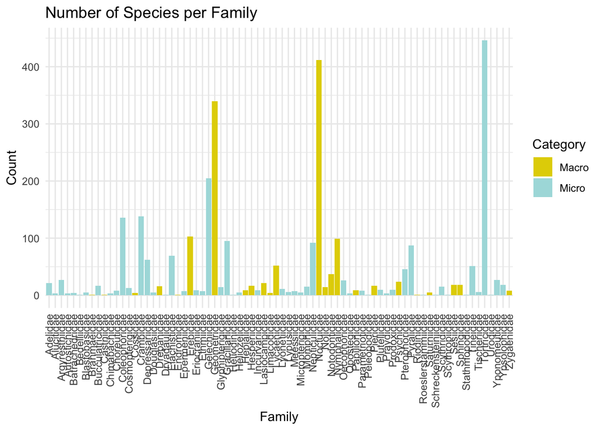

# Swedish fauna recovered by high-throughput survey.

We perform matching between IBA species names and the species reported in Sweden using DynTaxa online service. Details of how it was performed are in ../dyntaxa_searches

## How many of the Swedish species (n=2990) did we detect in IBA data?

```
## [1] 1535
```

```
## [1] "Metabarcoding survey succesfully detected 1535 known Swedish species. The ramaining 1455 were not found by high-throughput surveying."
```

## How many clusters had no match in Swedish fauna?

```
## [1] 2990
```

```
## [1] 2997
```

```
## [1] "Vetenskapligt.namn" "Svensk.förekomst"   "Rike"
## [4] "Fylum"              "Klass"              "Ordning"
## [7] "Familj"             "Släkte"             "Present_in_IBA"
```

```
## [1] "There were 74 clusters that did not match known Swedish fauna."
```

# Overall matching results. (Fig. 2A)

Barplot summarazing for whole Swedish fauna.

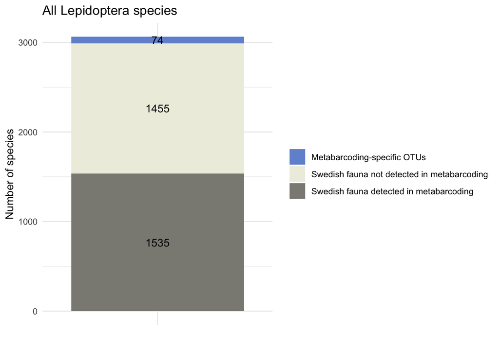

## How many species of each Family did we find in metabarcoding data?

Were there certain families that had many new clusters (species not matching known Swedish fauna)?

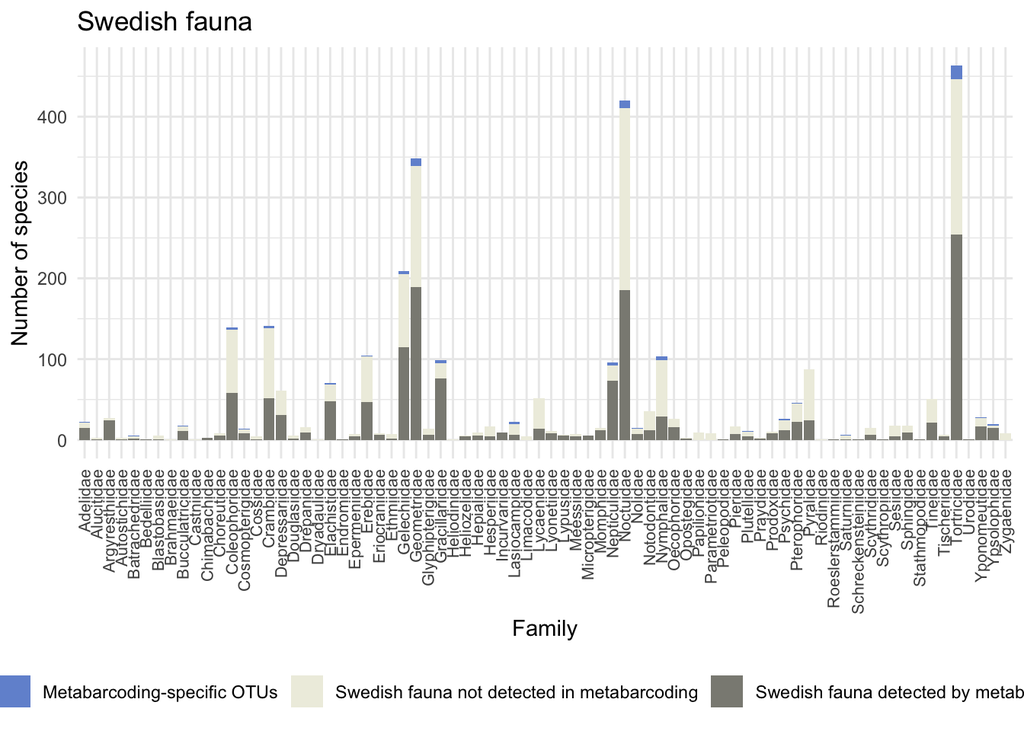

## How many species of each Family did we find in metabarcoding when looking at MICRO and MACRO Lepidoptera? - (Fig. 2 B and C)

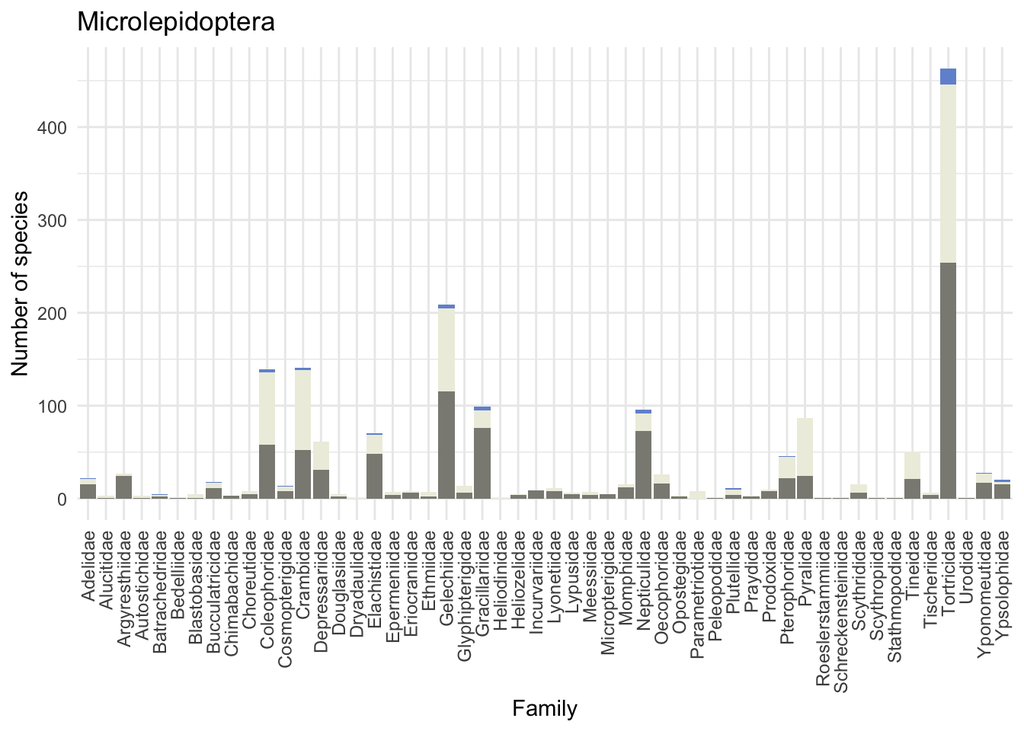

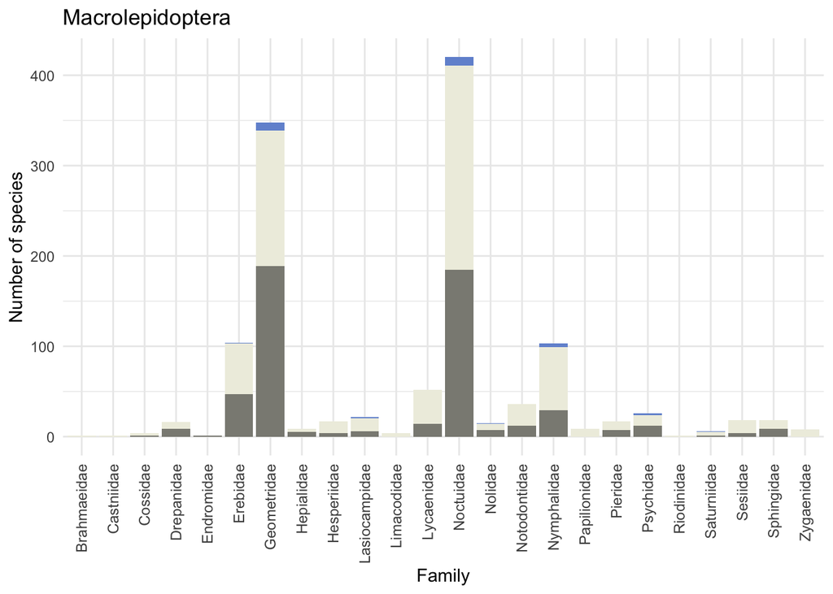

## Percentages of Swedish fauna recovered by metabarcoding by family and per category) - (Tab.S1)

```
##
##               MACRO micro
##   Meta only      29    45
##   not present   685   770
##   present       542   993
```

```
## [1] "The proportion of taxa detected across microlepidopteran families was 56.3244469653999"
```

```
## [1] "The proportion of taxa detected across MACROlepidopteran families was 44.1727791361043"
```

```
## [1] "The proportion of taxa detected across butterflies was 25"
```

# Which families were completely missed by metabarcoding?

```
## [1] "Metabarcoding did not detect any species in 9 families"
```

```
## [1] "Those families were Brahmaeidae"     "Those families were Castniidae"
## [3] "Those families were Dryadaulidae"    "Those families were Heliodinidae"
## [5] "Those families were Limacodidae"     "Those families were Papilionidae"
## [7] "Those families were Parametriotidae" "Those families were Riodinidae"
## [9] "Those families were Zygaenidae"
```

## How many of the natural residents (“Bofast och reproducerance”) did we detect in IBA collection

```
## [1] 1531
```

```
## [1] "High-throughtput survey covered 1531 out of total 2697 Sweden's natural resident species."
```